## Data manipulation

Load data

```r
music <- read.csv("datasets/music.csv")
# str shows variables on rows
str(music)
```

```
## 'data.frame':    62 obs. of  8 variables:
##  $ X     : chr  "Dancing Queen" "Knowing Me" "Take a Chance" "Mamma Mia" ...
##  $ Artist: chr  "Abba" "Abba" "Abba" "Abba" ...
##  $ Type  : chr  "Rock" "Rock" "Rock" "Rock" ...
##  $ LVar  : num  17600756 9543021 9049482 7557437 6282286 ...
##  $ LAve  : num  -90 -75.8 -98.1 -90.5 -89 ...
##  $ LMax  : int  29921 27626 26372 28898 27940 25531 14699 8928 22962 15517 ...
##  $ LFEner: num  106 103 102 102 100 ...
##  $ LFreq : num  59.6 58.5 124.6 48.8 74 ...
```

```r
# head shows the first few observations in a table
head(music)
```

```
##               X Artist Type     LVar      LAve  LMax   LFEner     LFreq
## 1 Dancing Queen   Abba Rock 17600756 -90.00687 29921 105.9210  59.57379
## 2    Knowing Me   Abba Rock  9543021 -75.76672 27626 102.8362  58.48031
## 3 Take a Chance   Abba Rock  9049482 -98.06292 26372 102.3249 124.59397
## 4     Mamma Mia   Abba Rock  7557437 -90.47106 28898 101.6165  48.76513
## 5   Lay All You   Abba Rock  6282286 -88.95263 27940 100.3008  74.02039
## 6 Super Trouper   Abba Rock  4665867 -69.02084 25531 100.2485  81.40140
```

Beware! In R we index from 1, not 0.

```r
music[1, 1]
```

```
## [1] "Dancing Queen"
```

Splicing works as well:

```r
music[c(1, 2, 3), 1]
```

```
## [1] "Dancing Queen" "Knowing Me"    "Take a Chance"
```

```r
music[1:3, 1]
```

```
## [1] "Dancing Queen" "Knowing Me"    "Take a Chance"
```

```r
music[1, ] # first ROW
```

```
##               X Artist Type     LVar      LAve  LMax  LFEner    LFreq
## 1 Dancing Queen   Abba Rock 17600756 -90.00687 29921 105.921 59.57379
```

```r
music[, 2] # second COLUMN
```

```
##  [1] "Abba"      "Abba"      "Abba"      "Abba"      "Abba"      "Abba"
##  [7] "Abba"      "Abba"      "Abba"      "Abba"      "Vivaldi"   "Vivaldi"
## [13] "Vivaldi"   "Vivaldi"   "Vivaldi"   "Vivaldi"   "Vivaldi"   "Vivaldi"
## [19] "Vivaldi"   "Vivaldi"   "Mozart"    "Mozart"    "Mozart"    "Mozart"
## [25] "Mozart"    "Mozart"    "Eels"      "Eels"      "Eels"      "Eels"
## [31] "Eels"      "Eels"      "Eels"      "Eels"      "Eels"      "Eels"
## [37] "Beatles"   "Beatles"   "Beatles"   "Beatles"   "Beatles"   "Beatles"
## [43] "Beatles"   "Beatles"   "Beatles"   "Beatles"   "Beethoven" "Beethoven"
## [49] "Beethoven" "Beethoven" "Beethoven" "Beethoven" "Beethoven" "Beethoven"
## [55] "Enya"      "Enya"      "Enya"      NA          NA          NA
## [61] NA          NA
```

Can also index using col names

```r
colnames(music)
```

```
## [1] "X"      "Artist" "Type"   "LVar"   "LAve"   "LMax"   "LFEner" "LFreq"
```

```r
music$Type
```

```
##  [1] "Rock"      "Rock"      "Rock"      "Rock"      "Rock"      "Rock"
##  [7] "Rock"      "Rock"      "Rock"      "Rock"      "Classical" "Classical"
## [13] "Classical" "Classical" "Classical" "Classical" "Classical" "Classical"
## [19] "Classical" "Classical" "Classical" "Classical" "Classical" "Classical"
## [25] "Classical" "Classical" "Rock"      "Rock"      "Rock"      "Rock"
## [31] "Rock"      "Rock"      "Rock"      "Rock"      "Rock"      "Rock"
## [37] "Rock"      "Rock"      "Rock"      "Rock"      "Rock"      "Rock"
## [43] "Rock"      "Rock"      "Rock"      "Rock"      "Classical" "Classical"
## [49] "Classical" "Classical" "Classical" "Classical" "Classical" "Classical"
## [55] "New wave"  "New wave"  "New wave"  NA          NA          NA
## [61] NA          NA
```

All `music$Type[1:10]`, `music[1:10,"Type"]`, and `music[1:10,3]` give the first 10 entries of the 3rd column.

How to get the last row

```r
music[nrow(music), ]
```

```
##    X Artist Type    LVar      LAve  LMax   LFEner    LFreq
## 62 5   <NA> <NA> 8651854 -6.132241 18509 83.88195 219.5377
```

```r
music[-(1:nrow(music) - 1), ] # the minus sign means "not" = everything except the first nrow(music)-1 rows
```

```
##    X Artist Type    LVar      LAve  LMax   LFEner    LFreq
## 62 5   <NA> <NA> 8651854 -6.132241 18509 83.88195 219.5377
```

## Exercise

- Obtain the entries in the music data frame corresponding to rows 1, 3 and 4 and columns 2 through 5.

```r
music[c(1, 3, 4), 2:5]
```

```
##   Artist Type     LVar      LAve
## 1   Abba Rock 17600756 -90.00687
## 3   Abba Rock  9049482 -98.06292
## 4   Abba Rock  7557437 -90.47106
```

- Obtain the entries in the music data frame corresponding to columns 4 through 8.

```r
music[, 4:8]
```

```
##           LVar        LAve  LMax    LFEner     LFreq
## 1   17600755.6 -90.0068667 29921 105.92095  59.57379
## 2    9543020.9 -75.7667187 27626 102.83616  58.48031
## 3    9049481.5 -98.0629244 26372 102.32488 124.59397
## 4    7557437.3 -90.4710616 28898 101.61648  48.76513
## 5    6282285.6 -88.9526309 27940 100.30076  74.02039
## 6    4665866.7 -69.0208450 25531 100.24848  81.40140
## 7    3369670.3 -71.6828788 14699 104.59686 305.18689
## 8    1135862.0 -67.8190467  8928 104.34921 277.66056
## 9    6146942.6 -76.2807500 22962 102.24066 165.15799
## 10   3482881.8 -74.1300038 15517 104.36243 146.73700
## 11   3677296.2  66.6530970 24229  99.25243 329.53792
## 12    771491.8  21.6560941  6936 104.36737 843.83240
## 13   5227573.2  88.6465556 17721 104.61255 165.76781
## 14    334719.1  13.8318847  4123 104.35005 293.99972
```

[output cut: 48 more lines]

## Plotting

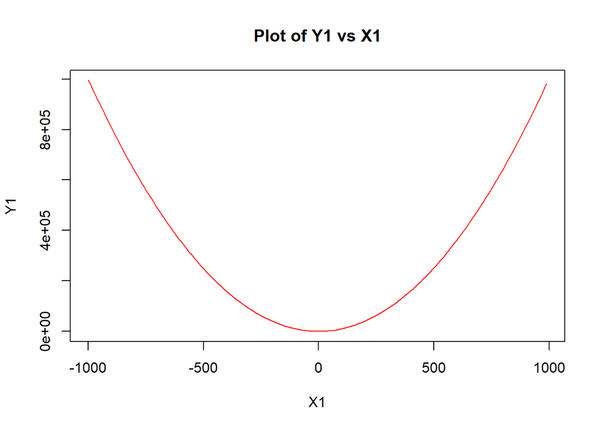

```r
X1 <- sample(-1000:1000, size = 200, replace = FALSE)
X1 <- sort(X1)
Y1 <- X1^2 + 3 * X1 + 1
plot(x = X1, y = Y1, type = "l", col = "red", main = "Plot of Y1 vs X1")
```

We can also use the `ggplot2` package to create a variety of aesthetically pleasing plots. `ggplot2` requires the data to be in the `data.frame` format. These plots are constructed via layers as seen below, where the `ggplot` function establishes basic details such as providing the `data.frame` and identifying the x and y variables, then `geom_line` adds the curve, and `labs` adds the title. This layering approach and the range of components which are available allows us to build up more complicated plots by combining different layers. Some nice examples of these plots can be seen at https://r-graph-gallery.com/, such as the final plot from https://r-graph-gallery.com/web-scatterplot-and-ggrepel.html, and more information about `ggplot2` can be found at https://ggplot2.tidyverse.org/.

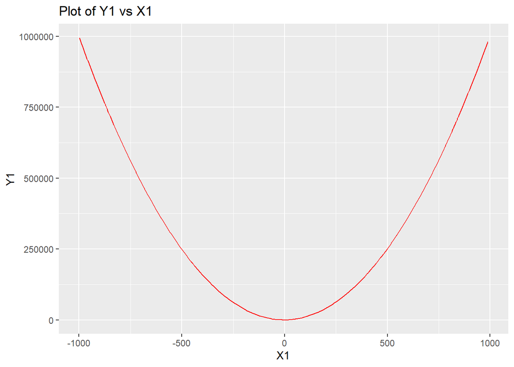

```r
library(ggplot2)

df <- data.frame(X1, Y1)
gg <- ggplot(data = df, mapping = aes(x = X1, y = Y1)) +
  geom_line(colour = "red") +
  labs(title = "Plot of Y1 vs X1")
gg
```

## Summary statistics

`R` has builtin functions `mean`, `sd`, `var`, `cov` and `cor`

The `music` dataset has numeric variables 4:8. Get the covariance matrix of these variables.

```r
C <- cov(music[, 4:8])
```

Scale the matrix to get the corelation matrix

```r
R <- matrix(0, nrow = dim(C)[1], ncol = dim(C)[2])
for (i in 1:dim(C)[1]) {
  for (j in 1:dim(C)[2]) {
    R[i, j] <- C[i, j] / sqrt(C[i, i] * C[j, j])
  }
}
print(R)
```

```
##            [,1]        [,2]       [,3]        [,4]       [,5]
## [1,]  1.0000000  0.11168505  0.6426304  0.69611717 -0.2609936
## [2,]  0.1116850  1.00000000 -0.0358804  0.01790643  0.1843789
## [3,]  0.6426304 -0.03588040  1.0000000  0.41376440 -0.2663298
## [4,]  0.6961172  0.01790643  0.4137644  1.00000000 -0.2682983
## [5,] -0.2609936  0.18437887 -0.2663298 -0.26829833  1.0000000
```

```r
cor(music[, 4:8])
```

```
##              LVar        LAve       LMax      LFEner      LFreq
## LVar    1.0000000  0.11168505  0.6426304  0.69611717 -0.2609936
## LAve    0.1116850  1.00000000 -0.0358804  0.01790643  0.1843789
## LMax    0.6426304 -0.03588040  1.0000000  0.41376440 -0.2663298
## LFEner  0.6961172  0.01790643  0.4137644  1.00000000 -0.2682983
## LFreq  -0.2609936  0.18437887 -0.2663298 -0.26829833  1.0000000
```

Plot LVar and LMax against each other.

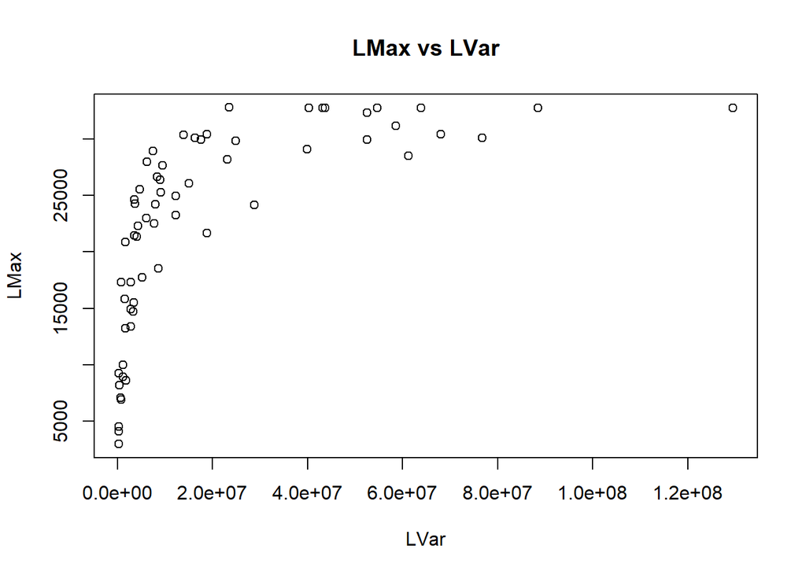

```r
plot(music$LVar, music$LMax, xlab = "LVar", ylab = "LMax", main = "LMax vs LVar")
```

Scale the data and plot again.

```r
music_scaled <- scale(music[, 4:8])
print(cov(music_scaled))
```

```
##              LVar        LAve       LMax      LFEner      LFreq
## LVar    1.0000000  0.11168505  0.6426304  0.69611717 -0.2609936
## LAve    0.1116850  1.00000000 -0.0358804  0.01790643  0.1843789
## LMax    0.6426304 -0.03588040  1.0000000  0.41376440 -0.2663298
## LFEner  0.6961172  0.01790643  0.4137644  1.00000000 -0.2682983
## LFreq  -0.2609936  0.18437887 -0.2663298 -0.26829833  1.0000000
```

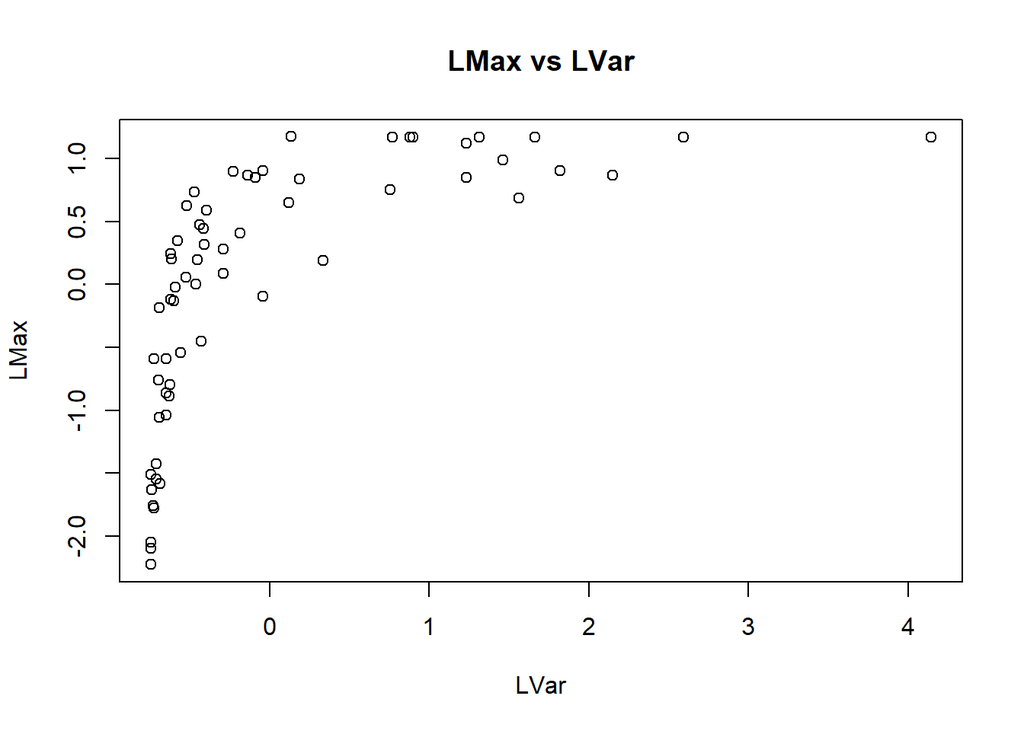

```r
plot(music_scaled[, 1], music_scaled[, 3], xlab = "LVar", ylab = "LMax", main = "LMax vs LVar")
```

## Basic Linear Algebra

The operator for matrix multiplication is `%*%`. The operator for element-wise multiplication is `*`.

```r
a <- c(1, 2, 3)
b <- c(4, 5, 6)
# element-wise multiplication
print(a * b)
```

```
## [1]  4 10 18
```

```r
# dot product
print(sum(a * b))
```

```
## [1] 32
```

```r
# or using matrix multiplication
print(a %*% b)
```

```
##      [,1]
## [1,]   32
```

```r
# transpose vector
print(t(b))
```

```
##      [,1] [,2] [,3]
## [1,]    4    5    6
```

```r
print(a %*% t(b))
```

```
##      [,1] [,2] [,3]
## [1,]    4    5    6
## [2,]    8   10   12
## [3,]   12   15   18
```

```r
# matrix multiplication
A <- matrix(c(1, 2, 3, 4, 5, 6), nrow = 2)
print(A)
```

```
##      [,1] [,2] [,3]
## [1,]    1    3    5
## [2,]    2    4    6
```

```r
B <- matrix(c(1, 2, 3, 4, 5, 6), nrow = 3)
print(B)
```

```
##      [,1] [,2]
## [1,]    1    4
## [2,]    2    5
## [3,]    3    6
```

```r
print(A %*% B)
```

```
##      [,1] [,2]
## [1,]   22   49
## [2,]   28   64
```

## Matrix Eigendecomposition

Use builtin `eigen` function. It returns a list with two components: `values` and `vectors`. Eigenvalues are in decreasing order and all eigenvectors are normalized to have length 1.

```r
res <- eigen(R)
print(res)
```

```
## eigen() decomposition
## $values
## [1] 2.3336465 1.1435388 0.7156333 0.5828106 0.2243708
##
## $vectors
##              [,1]        [,2]        [,3]        [,4]        [,5]
## [1,] -0.588904040 0.196723647 -0.12513976 -0.04870916  0.77230777
## [2,]  0.002332504 0.827745489  0.53255700  0.13474432 -0.11427589
## [3,] -0.513915382 0.002231933 -0.26614599  0.71598368 -0.39040964
## [4,] -0.532235892 0.099177521 -0.08449907 -0.67965669 -0.48766326
## [5,]  0.325273003 0.516038806 -0.78914467 -0.07003955 -0.01570279
```

We can access the eigenvectors and eigenvalues as follows:

```r
res$values
```

```
## [1] 2.3336465 1.1435388 0.7156333 0.5828106 0.2243708
```

```r
res$vectors
```

```
##              [,1]        [,2]        [,3]        [,4]        [,5]
## [1,] -0.588904040 0.196723647 -0.12513976 -0.04870916  0.77230777
## [2,]  0.002332504 0.827745489  0.53255700  0.13474432 -0.11427589
## [3,] -0.513915382 0.002231933 -0.26614599  0.71598368 -0.39040964
## [4,] -0.532235892 0.099177521 -0.08449907 -0.67965669 -0.48766326
## [5,]  0.325273003 0.516038806 -0.78914467 -0.07003955 -0.01570279
```

Check that the eigenvectors are normalized.

```r
for (i in 1:dim(res$vectors)[1]) {
  v <- res$vectors[, i]
  print(paste("Norm of vector", i, "is", sqrt(sum(v * v))))
}
```

```
## [1] "Norm of vector 1 is 1"
## [1] "Norm of vector 2 is 1"
## [1] "Norm of vector 3 is 1"
## [1] "Norm of vector 4 is 1"
## [1] "Norm of vector 5 is 1"
```

Breaks down if `A` is not diagonalizable.

```r
A <- matrix(c(3, 1, 2, 0, 3, 4, 0, 0, 3), nrow = 3)
eigen(A)
```

```
## eigen() decomposition
## $values
## [1] 3 3 3
##
## $vectors
##      [,1]          [,2]          [,3]
## [1,]    0  0.000000e+00  1.109336e-31
## [2,]    0  1.665335e-16 -1.665335e-16
## [3,]    1 -1.000000e+00  1.000000e+00
```

Let’s check that they are indeed eigenvectors and eigenvalues.

```r
R %*% res$vectors
```

```
##             [,1]        [,2]        [,3]        [,4]         [,5]
## [1,] -1.37429386 0.224961119 -0.08955417 -0.02838821  0.173283336
## [2,]  0.00544324 0.946559063  0.38111550  0.07853042 -0.025640175
## [3,] -1.19929684 0.002552302 -0.19046292  0.41728289 -0.087596535
## [4,] -1.24205043 0.113413341 -0.06047035 -0.39611114 -0.109417411
## [5,]  0.75907221 0.590110384 -0.56473818 -0.04081979 -0.003523249
```

```r
res$vectors * res$values
```

```
##              [,1]        [,2]        [,3]        [,4]         [,5]
## [1,] -1.374293862 0.459083454 -0.29203196 -0.11366996  1.802293345
## [2,]  0.002667309 0.946559063  0.60899957  0.15408536 -0.130678906
## [3,] -0.367774943 0.001597246 -0.19046292  0.51238173 -0.279390126
## [4,] -0.310192727 0.057801712 -0.04924696 -0.39611114 -0.284215326
## [5,]  0.072981773 0.115784055 -0.17706104 -0.01571483 -0.003523249
```

### Exercise

- Write a function for returning the largest eigenvalue of a matrix.

```r
largest_eigenvalue <- function(A) {
  res <- eigen(A)
  return(res$values[1])
}

largest_eigenvalue(R)
```

```
## [1] 2.333647
```

- check that the eigenvectors are indeed eigenvectors and the eigenvalues are indeed eigenvalues using diagonalization.

Because the covariance matrix is symmetric, it can be diagonalized as $R = PDP^T$, where $P$ is the matrix of eigenvectors and $D$ is the diagonal matrix of eigenvalues.

```r
print(R)
```

```
##            [,1]        [,2]       [,3]        [,4]       [,5]
## [1,]  1.0000000  0.11168505  0.6426304  0.69611717 -0.2609936
## [2,]  0.1116850  1.00000000 -0.0358804  0.01790643  0.1843789
## [3,]  0.6426304 -0.03588040  1.0000000  0.41376440 -0.2663298
## [4,]  0.6961172  0.01790643  0.4137644  1.00000000 -0.2682983
## [5,] -0.2609936  0.18437887 -0.2663298 -0.26829833  1.0000000
```

```r
print(diag(res$values))
```

```
##          [,1]     [,2]      [,3]      [,4]      [,5]
## [1,] 2.333647 0.000000 0.0000000 0.0000000 0.0000000
## [2,] 0.000000 1.143539 0.0000000 0.0000000 0.0000000
## [3,] 0.000000 0.000000 0.7156333 0.0000000 0.0000000
## [4,] 0.000000 0.000000 0.0000000 0.5828106 0.0000000
## [5,] 0.000000 0.000000 0.0000000 0.0000000 0.2243708
```

```r
print(res$vectors %*% diag(res$values) %*% t(res$vectors))
```

```
##            [,1]        [,2]       [,3]        [,4]       [,5]
## [1,]  1.0000000  0.11168505  0.6426304  0.69611717 -0.2609936
## [2,]  0.1116850  1.00000000 -0.0358804  0.01790643  0.1843789
## [3,]  0.6426304 -0.03588040  1.0000000  0.41376440 -0.2663298
## [4,]  0.6961172  0.01790643  0.4137644  1.00000000 -0.2682983
## [5,] -0.2609936  0.18437887 -0.2663298 -0.26829833  1.0000000
```